# What hahppens When Normality Assumption is Violated

Mehedi Hasan Jim

2025-07-19

How does Ordinary Least Square estimator behave if the residuals are not normally distributed? Ever thought of that? Usually we check whether the residuals are following normal distribution or not. But how important is this assumption? Say, we have continuous x,y variable, ignoring the discrete case, as discrete y usually brings GLM with it.

Let’s consider the follwoing distributions for the residual and generate data.

- Exponential
- Normal
- Weibull

You can choose other distributions too. But for this instance, these are good to compare.

We will simulate data for the follwoing model:

$$Y = 15 + 0.6 X_1 + 2 X_2 + U$$

For this work, we have chosen $X_1$ and $X_2$ to be generated from uniform distribution. We have taken 100 iteration for samples of sizes : 15, 100 and 400

```r
# install the required packages crom CRAN at first
# install.packages("tidyverse")
# install.packages("kableExtra")
# install.packages("latex2exp")

set.seed(123)
library(tidyverse)
library(kableExtra)
library(latex2exp)
simulate <- function(x, n, distribution, ...){
  u <- if (distribution == "exponential") {
    rexp(n, ...)
  } else if (distribution == "weibull") {
    rweibull(n, ...)
  } else if (distribution == "normal") {
    rnorm(n, ...)
  } else {
    stop("Unsupported distribution")
  }
  x1 = runif(n, min = 45, max = 60)

  x2 = runif(n, min = 20, max = 30)


  y = 15+ 0.6 * x1 + 2 * x2 + u

  fit <- lm(y~x1+x2) |> summary()
  result <- data.frame(
    distribution = distribution,
    sample_size = n,
    beta1 = fit$coefficients[2],
    beta2 = fit$coefficients[3])
  return(result)
}

sim_result <- pmap_df(list(x = 1:900,
                           n = rep(c(rep(15,100),
                                 rep(100, 100),
                                 rep(400, 100)),3),
                           distribution = c(rep("exponential", 300),
                                            rep("weibull", 300),
                                            rep("normal", 300)),
                           c(rate = rep(2, 300),
                                shape = rep(2,300),
                                mean = rep(0,300))),
                      .f= simulate)

simulation <- sim_result %>% group_by(sample_size, distribution) %>% summarise(across(beta1:beta2,
                 list(mean = ~round(mean(.x),3),
                      sd = ~round(sd(.x), 3)),
                 .names = "{.col}_{.fn}")) %>% mutate(sample_size = as.numeric(sample_size)) %>% arrange(sample_size) %>%
  mutate(distribution = str_to_title(distribution)) %>%  rename_with(str_to_title)
simulation |> kable(align = "c")
```

| Sample_size | Distribution | Beta1_mean | Beta1_sd | Beta2_mean | Beta2_sd |
| --- | --- | --- | --- | --- | --- |
| 15 | Exponential | 0.601 | 0.036 | 2.004 | 0.050 |
| 15 | Normal | 0.598 | 0.067 | 2.006 | 0.091 |
| 15 | Weibull | 0.603 | 0.031 | 2.002 | 0.051 |
| 100 | Exponential | 0.601 | 0.012 | 2.002 | 0.017 |
| 100 | Normal | 0.600 | 0.021 | 1.999 | 0.034 |
| 100 | Weibull | 0.600 | 0.011 | 2.001 | 0.016 |
| 400 | Exponential | 0.600 | 0.005 | 2.001 | 0.009 |
| 400 | Normal | 0.600 | 0.011 | 1.999 | 0.018 |
| 400 | Weibull | 0.600 | 0.006 | 2.001 | 0.008 |

we may want to generate the distribution of $\hat \beta_1$ and $\hat \beta_2$

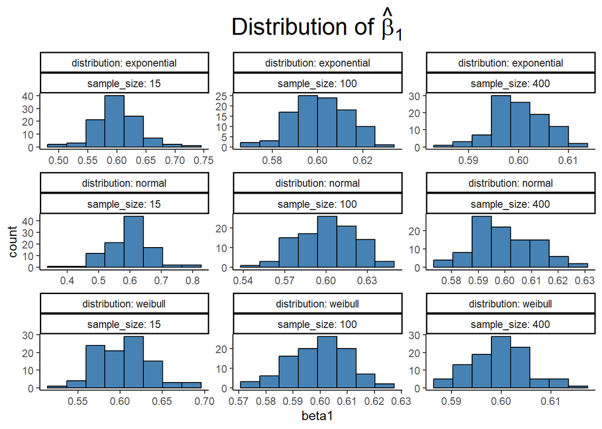

```r
ggplot(sim_result)+
  geom_histogram(aes(beta1),
                 bins = 8,
                 fill = "steelblue",
                 color = "black")+
  labs(title = expression(paste("Distribution of ",hat(beta)[1])))+ # used exp
  facet_wrap(~distribution+sample_size,
             scales = "free",
             labeller = label_both)+
  theme_classic()+
  theme(plot.title = element_text(hjust = 0.5,
                                  size = 20,
                                  color = "black"))
```

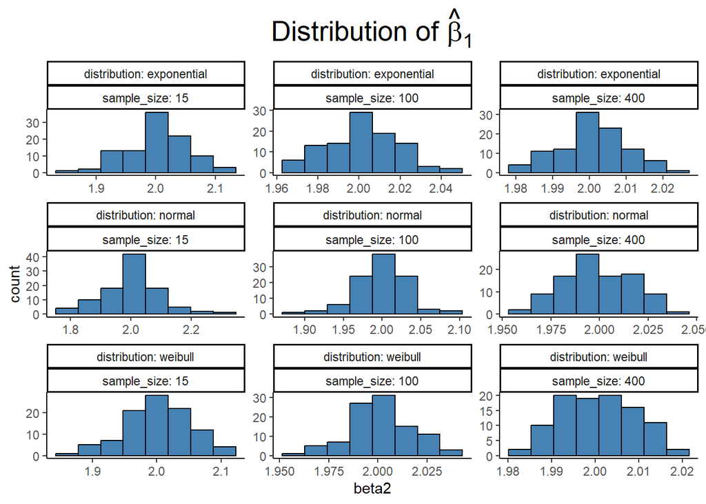

```r
library(latex2exp)
ggplot(sim_result)+
  geom_histogram(aes(beta2),
                 bins = 8, fill = "steelblue",
                 color = "black")+
  facet_wrap(~distribution+sample_size,
             scales = "free",
             labeller = label_both)+

  labs(title = TeX("Distribution of $\\hat{\\beta}_1$"))+ # used latex2exp

  theme_classic()+
  theme(plot.title = element_text(hjust = 0.5,
                                  size = 20,
                                  color = "black"))
```

The Table of means and standard errors for the residual following different distributions for different sample size, along with the plots of the estimates clearly show that **violation of the normality assumption has little to no impact on the biasness and efficiency of the estimator.**